# 3.1 Loop Closure

ORB-SLAM3 — Wiedererkennung besuchter Orte & Drift-Erkennung

Autor:in

Gruppe 9-2

Veröffentlichungsdatum

2. Juli 2026

## Agenda

1. Warum Loop Closure? — Das Drift-Problem
2. **Schritt 1:** Trajektorie analysieren — Wo könnte ein Loop sein?
3. **Schritt 2:** Place Recognition — Bag of Visual Words
4. **Schritt 3:** Similarity-Matrix & Loop Candidates
5. **Schritt 4:** Geometrische Verifikation
6. **Ergebnis:** Verifizierte Loop-Closure-Kanten

**Wichtig**

**Anknüpfung an 2.2:** Nach der lokalen Optimierung (Bundle Adjustment) haben wir eine konsistente **lokale** Karte. Aber über lange Distanzen akkumuliert sich Drift — das System „vergisst”, wo es schon war. Loop Closure erkennt die Wiederkehr an einen bekannten Ort und liefert die Constraints für die globale Korrektur in 3.2.

## Problem: Drift über lange Trajektorien

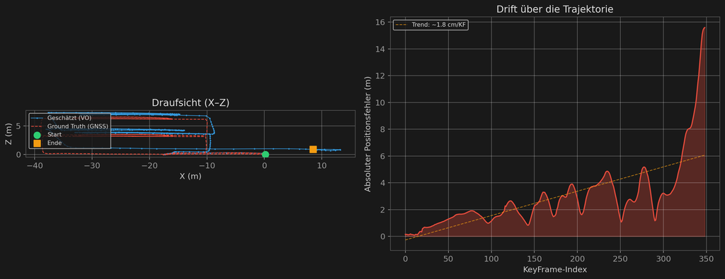

Abbildung 1: Kameratrajektorie mit sichtbarem Drift vs. Ground Truth

**Hinweis**

Der Drift wächst mit der zurückgelegten Distanz kontinuierlich an. Nach dem gesamten Pfad beträgt der absolute Fehler mehrere Meter. Ohne Loop Closure würde die Karte immer weiter auseinanderlaufen.

## Schritt 1: Wo sind die Loop-Kandidaten?

Bevor aufwändige Bildvergleiche stattfinden, identifizieren wir räumliche Nähe: Zwei KeyFrames, die **nah im Raum** aber **weit in der Zeit** auseinanderliegen.

```
Räumliche Loop-Kandidaten (roh): 236
Davon gefiltert (einer pro Cluster): 84
  KF  23 ↔ KF 329  |  Dist: 0.92 m  |  Δt: 306 Frames
  KF  57 ↔ KF  99  |  Dist: 1.14 m  |  Δt: 42 Frames
  KF  57 ↔ KF 100  |  Dist: 1.00 m  |  Δt: 43 Frames
  KF  58 ↔ KF 101  |  Dist: 1.05 m  |  Δt: 43 Frames
  KF  58 ↔ KF 257  |  Dist: 0.95 m  |  Δt: 199 Frames
  KF  58 ↔ KF 296  |  Dist: 0.66 m  |  Δt: 238 Frames
  KF  59 ↔ KF 258  |  Dist: 0.74 m  |  Δt: 199 Frames
  KF  59 ↔ KF 297  |  Dist: 1.46 m  |  Δt: 238 Frames
```

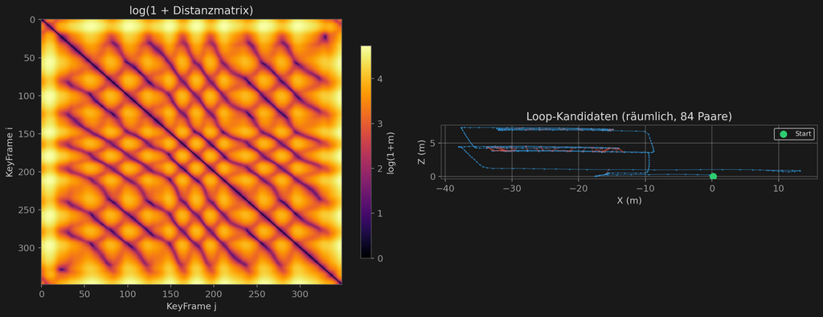

Abbildung 2: Räumliche Distanzmatrix und Loop-Kandidaten

## Schritt 2: Place Recognition — Bag of Visual Words

In einem realen ORB-SLAM3-System werden ORB-Deskriptoren aus den Bildern extrahiert und über k-Means zu einem visuellen Wörterbuch geclustert. Wir verwenden die räumliche Verteilung der 3D-Punkte als Proxy — das Prinzip ist dasselbe.

```
Vokabular: 50 visuelle Wörter (20 Iterationen)
```

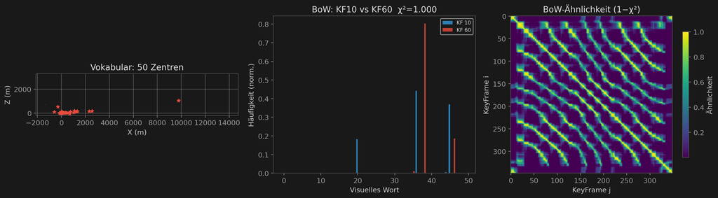

Abbildung 3: Bag of Visual Words — Vokabular aus 3D-Punkt-Merkmalen

## Schritt 3: Kombiniertes Scoring & Loop-Selektion

```
Top 8 Loop-Kandidaten (BoW + räumliche Nähe):
  #1: KF255↔KF294  BoW-Sim=0.951  Dist=0.06m  Score=86
  #2: KF244↔KF284  BoW-Sim=0.994  Dist=0.21m  Score=82
  #3: KF 69↔KF113  BoW-Sim=0.989  Dist=0.28m  Score=77
  #4: KF167↔KF199  BoW-Sim=0.988  Dist=0.30m  Score=76
  #5: KF256↔KF295  BoW-Sim=0.938  Dist=0.26m  Score=74
  #6: KF 82↔KF124  BoW-Sim=0.891  Dist=0.23m  Score=72
  #7: KF 70↔KF114  BoW-Sim=0.982  Dist=0.40m  Score=70
  #8: KF166↔KF198  BoW-Sim=0.981  Dist=0.46m  Score=67
```

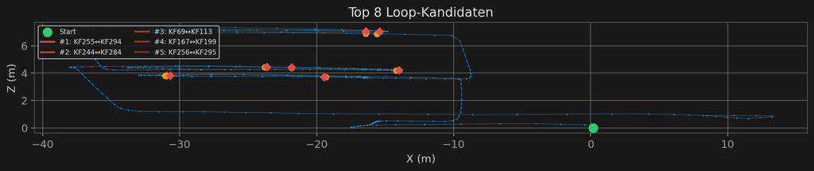

Abbildung 4: Beste Loop-Kandidaten via kombiniertem BoW + räumlichem Scoring

## Schritt 4: Geometrische Verifikation

Jeder Kandidat wird geometrisch geprüft: Wie viele 3D-Punkte beider Frames liegen in derselben Weltregion? Eine hohe Überlappung bestätigt den Loop.

```
Geometrische Verifikation:

Rank  Paar          Inlier-Ratio  Inliers   Verifiziert?
------------------------------------------------------------
#1     KF255↔KF294  0.400        178        ✓ JA
#2     KF244↔KF284  0.511        267        ✓ JA
#3     KF 69↔KF113  0.446        221        ✓ JA
#4     KF167↔KF199  0.415        226        ✓ JA
#5     KF256↔KF295  0.391        194        ✓ JA
#6     KF 82↔KF124  0.283        163        ✓ JA
#7     KF 70↔KF114  0.378        185        ✓ JA
#8     KF166↔KF198  0.535        278        ✓ JA

Verifiziert: 8/8
```

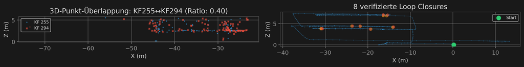

Abbildung 5: Geometrische Verifikation der Loop-Kandidaten

## Konkretes Beispiel: Loop Closure mit echten Kameradaten

Der am höchsten bewertete Loop (#1) ist **KF255 ↔︎ KF294** mit 40% Punkt-Überlappung. Hier sehen wir die tatsächlichen Kamerabilder — Frames, die per ffmpeg an der passenden Zeitposition aus dem Video extrahiert wurden.

```
Bester Loop: KF255 ↔ KF294
  Überlappung: 40%
  Gemeinsame 3D-Punkte: 178
  Räumliche Distanz: 0.06 m
  Zeitlicher Abstand: 195 Original-Frames
KF255: 445 sichtbare Punkte, 800×400
KF294: 522 sichtbare Punkte, 800×400
```

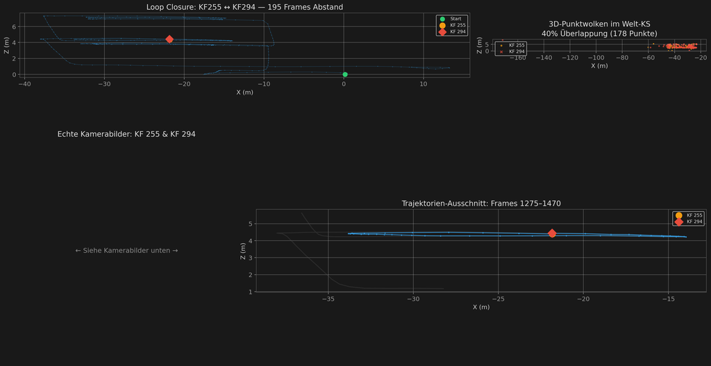

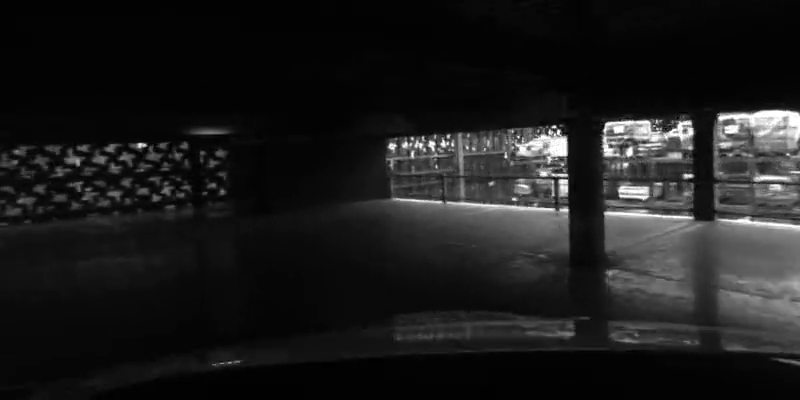

KF 255 — Frühere Aufnahme

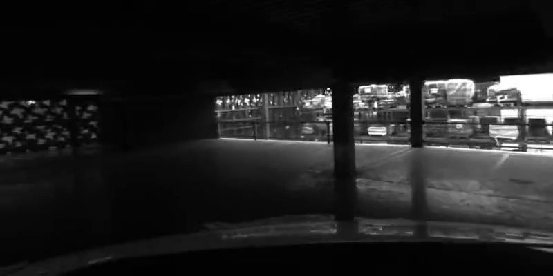

KF 294 — Spätere Aufnahme

## Ergebnis: Loop-Closure Constraints für 3.2

```
============================================================
ZUSAMMENFASSUNG — Loop Closure Detection
============================================================
KeyFrames:           349
Pfadlänge:           1029.3 m
Max. Drift:          15.59 m
Räumliche Kandidaten: 84
Verifizierte Loops:   8

→ Diese Constraints fließen in die Pose-Graph-Optimierung (3.2) ein.
============================================================

✓ loop_constraints.json gespeichert
```